# Phase 3: DRY PEAS Agricultural Commodity Loss Variations across the Pacific Northwest Palouse Region, 1989-2015 - Mixed Modeling Analysis

Erich Seamon

9/25/2018

## Introduction

This analysis explores the relationships of agricultural commodity loss, at a county level, from 1989-2015, for the 26 county region of the Palouse, in Washington, Idaho, and Oregon. Here we explore the entire range of commodities and damage causes, identifying the top revenue loss commodities and their most pertinent damage causes - as indicated from the USDA’s agricultural commodity loss insurance archive.

## Phase 3

In Phase 3, we perform a DRY PEAS mixed modeling analysis using a two-step hurdle technique, for a selected set of damage causes. The following analysis builds on Phases 1 and 2.

## Hurdle Mixed Models

Hurdle model techniques allow us to address zero inflated datasets, by first running a logstical regression model to determine the probability of zeros occuring. Then we use the non-zero values in a separate, mixed model. In this instance, we use county as a random effect.

In our two part hurdle model, we identify zero values - that is, counties and years that have zero loss for particular damage causes for dry peas Previously we removed counties that we have determined have no dry peas being grown - based on known crop yield data. The counties we are identifying are those where we KNOW dry peas are being grown, but in some instances, there are no loss claims being filed in particular years.

As such, these are not missing data, but actual zero values that we do not want to exclude from our model. However we want to be able to use a normalized distribution that is not positively skewed/zero inflated.

## Hurdle Model - DRY PEAS

Here we run our hurdle technique for DRY PEAS, using a generalized linear model with a binomal function to delineate between zero and non-zero values. Given this model, Is our data normally distributed? What (if any) outliers exist? Are residuals well distributed - indicating normality?

### Dry Peas Non-zero Goodness of fit hoslem test

```
##           llh       llhNull            G2      McFadden          r2ML
##  -755.4688136 -1138.2908423   765.6440573     0.3363130     0.3129277
##          r2CU
##     0.4653870
```

```
##
##  Hosmer and Lemeshow goodness of fit (GOF) test
##
## data:  alllevs2_drypeas$non_zero, fitted(m1)
## X-squared = 15.916, df = 8, p-value = 0.04359
```

### Dry Peas zero/non-zero bionomal model to see outliers and zeros values vs non-zero values

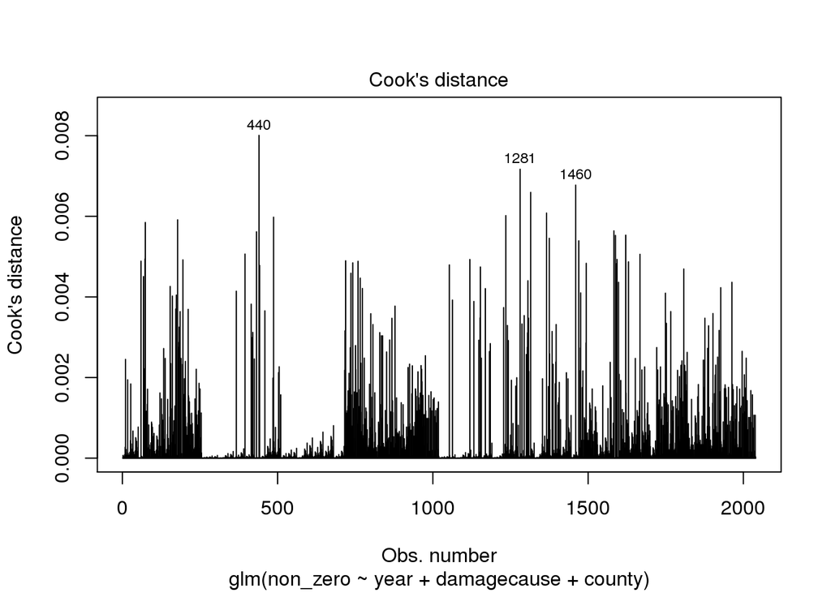

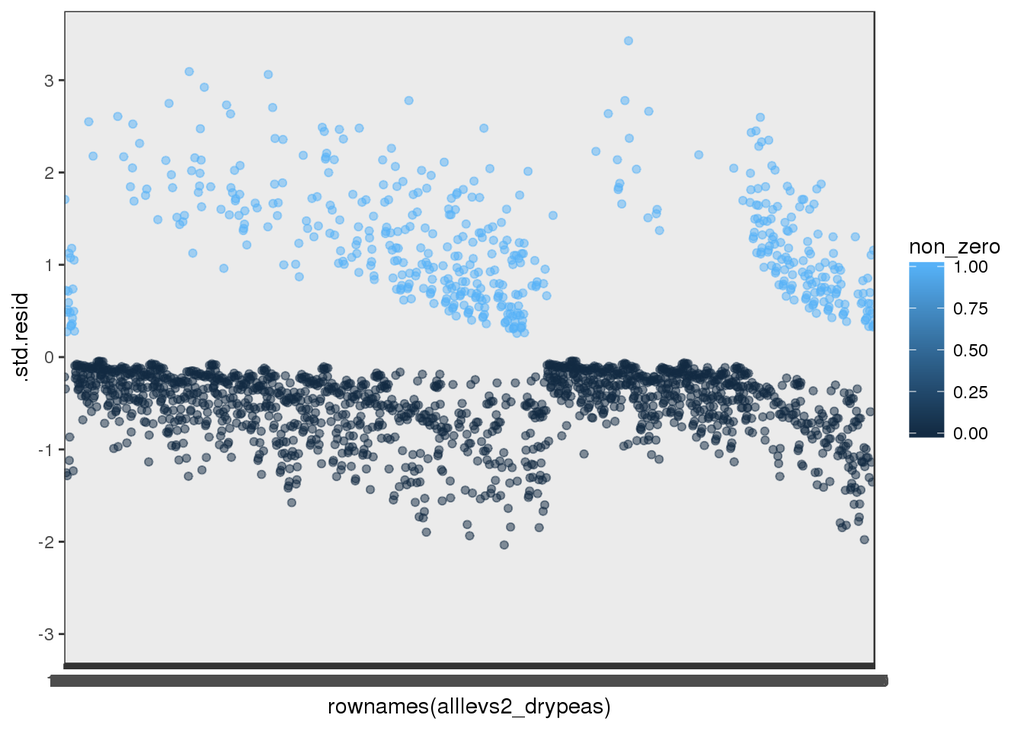

### Checking for multi collinearity

```
##              GVIF Df GVIF^(1/(2*Df))
## year        1.127 14           1.004
## damagecause 1.252  7           1.016
## county      1.204 16           1.006
```

### Dry peas binomal model summary for only significant factors

```
##                                   pvalue
## (Intercept)                 5.680448e-15
## year2004                    1.464387e-02
## year2005                    2.639060e-02
## year2006                    3.976504e-03
## year2008                    4.524246e-04
## year2010                    4.014582e-05
## year2013                    7.055451e-07
## year2014                    1.671235e-09
## year2015                    3.693502e-09
## damagecauseCold Winter      2.226158e-08
## damagecauseDecline in Price 5.561696e-04
## damagecauseDrought          9.375153e-15
## damagecauseFreeze           9.218116e-08
## damagecauseFrost            1.709808e-02
## damagecauseHeat             1.198942e-16
## countyBenewah               2.015166e-05
## countyClearwater            1.325723e-02
## countyColumbia              4.800879e-04
## countyIdaho                 5.201667e-06
## countyLatah                 1.322814e-10
## countyLewis                 2.978090e-10
## countyNez Perce             1.474119e-09
## countySpokane               1.461164e-07
## countyUmatilla              2.166802e-02
## countyWalla Walla           1.029674e-05
## countyWhitman               3.660009e-13
```

### Dry Peas mixed model coefficient estimates for damage cause and year

Now subset to just those Dry Peas observations with a loss greater than zero (so all non-zeros), and run a linear regression (switched to log loss due to outliers), to make sure that our residuals and other parameters suggest normality.

```
## Linear mixed model fit by REML ['lmerMod']
## Formula: log(loss) ~ year + damagecause + (1 | county)
##    Data: subset(alllevs2_drypeas, non_zero == 1)
##
## REML criterion at convergence: 1860
##
## Scaled residuals:
##     Min      1Q  Median      3Q     Max
## -3.9544 -0.4928  0.1551  0.6655  2.1097
##
## Random effects:
##  Groups   Name        Variance Std.Dev.
##  county   (Intercept) 0.3996   0.6321
##  Residual             2.2811   1.5103
## Number of obs: 502, groups:  county, 17
##
## Fixed effects:
##                             Estimate Std. Error t value
## (Intercept)                   6.4011     0.4337  14.758
## year2002                      1.1477     0.4605   2.492
## year2003                      1.7577     0.4493   3.912
## year2004                      1.6750     0.6272   2.670
## year2005                      2.2060     0.4360   5.059
## year2006                      1.3581     0.4271   3.180
## year2007                      1.6262     0.4486   3.625
## year2008                      2.4535     0.4210   5.828
## year2009                      1.8246     0.4456   4.095
## year2010                      2.3902     0.4191   5.703
## year2011                      2.0400     0.5166   3.949
## year2012                      2.2563     0.4510   5.003
## year2013                      2.4718     0.4136   5.977
## year2014                      2.9396     0.4059   7.243
## year2015                      3.8526     0.4023   9.577
## damagecauseCold Winter       -0.6207     0.4355  -1.425
## damagecauseDecline in Price  -0.4614     0.3677  -1.255
## damagecauseDrought            0.4783     0.2587   1.849
## damagecauseFreeze            -0.9689     0.4255  -2.277
## damagecauseFrost             -0.2361     0.3297  -0.716
## damagecauseHail               0.3804     0.2905   1.309
## damagecauseHeat               0.2298     0.2515   0.914
```

### Residuals vs fitted values

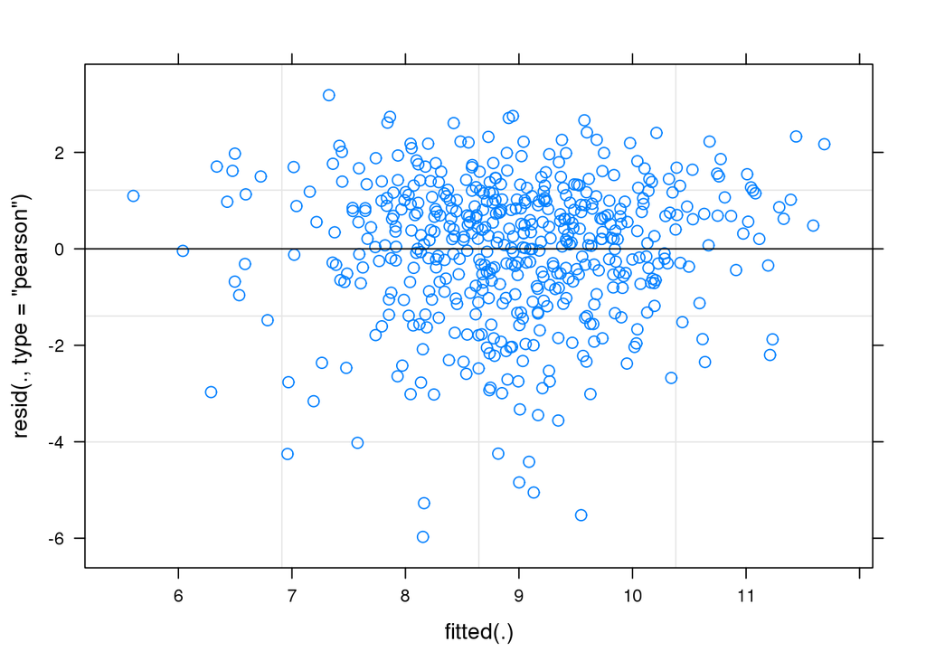

### We examine the DRY PEAS coefficent estimates of our model output.

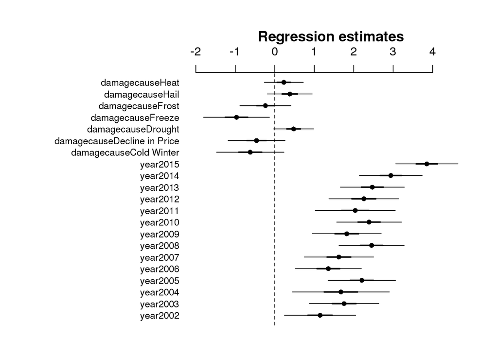

### Finally, we exponentiate the coefficient estimates and confidence intervals for odds ratios.

```
##                              rn      lower       upper   estimate stderror
##  1:                    year2002  1.3017723   7.6412632  3.1510220 1.584912
##  2:                    year2003  2.4469410  13.7523548  5.7990471 1.567200
##  3:                    year2004  1.6018655  17.8527384  5.3388800 1.872447
##  4:                    year2005  3.9293215  20.9850703  9.0796703 1.546574
##  5:                    year2006  1.7129457   8.8396657  3.8887481 1.532749
##  6:                    year2007  2.1497273  12.0563155  5.0844397 1.566053
##  7:                    year2008  5.1830773  26.1285021 11.6295078 1.523426
##  8:                    year2009  2.6352492  14.5996543  6.2000068 1.561365
##  9:                    year2010  4.8811790  24.4259125 10.9157261 1.520577
## 10:                    year2011  2.8537106  20.8210658  7.6903393 1.676387
## 11:                    year2012  4.0176232  22.7341095  9.5473067 1.569822
## 12:                    year2013  5.3546238  26.2384348 11.8432900 1.512191
## 13:                    year2014  8.6741820  41.2573245 18.9087670 1.500614
## 14:                    year2015 21.7649829 102.1191780 47.1175633 1.495241
## 15:      damagecauseCold Winter  0.2330977   1.2458334  0.5375878 1.545689
## 16: damagecauseDecline in Price  0.3109437   1.2771526  0.6304087 1.444388
## 17:          damagecauseDrought  0.9812936   2.6511404  1.6132606 1.295214
## 18:           damagecauseFreeze  0.1677002   0.8607936  0.3795095 1.530426
## 19:            damagecauseFrost  0.4194035   1.4890046  0.7897253 1.390562
## 20:             damagecauseHail  0.8377201   2.5599627  1.4629353 1.337147
## 21:             damagecauseHeat  0.7758169   2.0391972  1.2582955 1.285938
##                              rn      lower       upper   estimate stderror
```

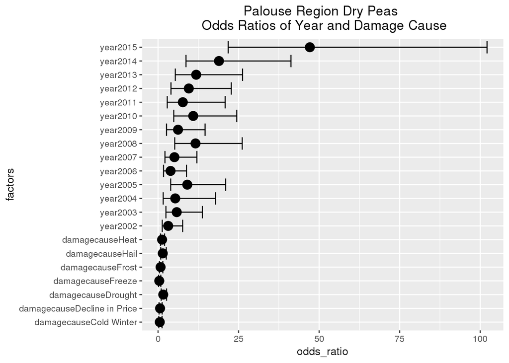